# R: Files

Patrick Ho

2018-08-04

### Tabular Data

```
# Read
infile <- 'input.csv'
df <- read.table(file = infile,
                 header = TRUE,  # Has header line?
                 sep = ',',  # Separator character
                 nrows = 100,  # Number of rows to read
                 comment.char = '#',  # Skip rows starting with this character
                 skip = 2, # Skip this many rows from start
                 stringsAsFactors = TRUE)  # Encode chars as factors
df <- read.csv(infile)  # Same as read.table() with comma as default separator


# Read large files
sample <- read.table('large_file.csv', nrows = 100)
classes <- sapply(sample, class)
df <- read.table('large_file.csv',
                 colClasses = classes,  # Pre-defining column classes is much faster
                 nrows = 50000)  # Pre-defining rows (Unix wc) can help with memory usage


# Write
outfile <- 'output.csv'
write.table(df,
            file = outfile,
            append = FALSE)  # FALSE will overwrite
write.csv(df, outfile)
```

### R Objects

- Text format and includes meta-data
- Easy to edit but less space efficient
- Works nicely with version control programs like git
- **dget** pairs with **dput**
- **source** pairs with **dump**

```
# Read
dget('data.R')

source('data.R')

# Write
df <- data.frame(a = 1, b = 'b')
dput(df)  # Prints out structure
dput(df, 'data.R')

x <- 5
y <- 'abc'
dump(c('x','y','df'), file = 'data.R')
```

### Connections

##### Interfaces

- file()
- gzfile() = connection to gzip compressed file
- url() = connection to webpage

##### Modes

- 'r' = read only
- 'w' = writing/creating
- 'a' = appending
- 'rb', 'wb', 'ab' = read/write/append in binary mode (Windows)

```
# Read
con <- file('input.csv', 'r')
con <- gzfile('input.gz', 'r')
con <- url('http://cran.r-project.org/', 'r')
x <- readLines(con, 10)  # Read in first 10 lines
close(con)
```

### Workspace

```
# Read
load('mydata.RData')

# Write
save.image(file = 'mydata.Rdata')  # Defaults to '.Rdata' if not specified
```

# R: Dates/Times

Patrick Ho

2018-08-04

### Dates

- Dates represented by **Date** class
- Stored as days since 1970-01-01

```
x <- as.Date('1970-01-01')
unclass(x)  # 0

x <- as.Date('2017-01-01')
unclass(x)  # 17167


# Operations
x <- as.Date("2016-03-01")
y <- as.Date("2016-02-28")
x-y  # Time difference of 2 days  (keeps track of leap years)
```

### Times

- Times represented by:
  - **POSIXct** - compact time, just the number of seconds
  - **POSIXlt** - list time, list of different representations
- Stored as seconds since 1970-01-01

```
x <- Sys.time()  # "2017-02-12 19:54:32 GMT"
class(x)  # "POSIXct" "POSIXt"
unclass(x)  # 1486929273 seconds

p <- as.POSIXlt(x)
names(unclass(p))  # "sec"    "min"    "hour"   "mday" etc.
p$sec  # 32.98549
p$min  # 54


# Convert string to time
date_strings <- c("10 February, 2017 9:40", "15 March, 2017 18:10")
x <- strptime(date_strings, "%d %B, %Y %H:%M")  # "2017-02-10 09:40:00 GMT" "2017-03-15 18:10:00 GMT"
class(x)  # "POSIXlt" "POSIXt"


# Operations
x <- strptime("1 Feb 2017 12:34:56", "%d %b %Y %H:%M:%S")
y <- as.Date("2017-01-10")
y <- as.POSIXlt(y)  # Convert from Date to POSIXlt to match x
x-y  # Time difference of 22.52426
```

# R: Control Flow

Patrick Ho

2018-08-04

### If

- Be careful of short form (&, |) vs long form (&&, ||) logical operators
  - Short form does element-wise comparison
  - Long form evaluates left to right using only first element of each vector
  - Long form preferred in if clauses, just ensure it's a single element comparison

```
if (x > 5) {
  y <- 6
} else if (x == 5) {
  y <- 5
} else {
  y <- 0
}

# Short form logical operators
((-2:2) >= 0) & ((-2:2) <= 0)   # FALSE FALSE  TRUE FALSE FALSE

# Long form logical operators
((-2:2) >= 0) && ((-2:2) <= 0)  # FALSE  (-2 not >= 0)
```

### For

```
for (i in 1:10) {
  print(i)
}


# Process a vector - Following loops all have same result
x <- c('a', 'b', 'c', 'd', 'e')

for (i in 1:5) {
  print(x[i])
}

for (i in seq_len(length(x))) {
  print(x[i])
}

for (i in seq_along(x)) {
  print(x[i])
}

for (letter in x) {
  print(letter)
}


# Nested loops
x <- matrix(1:6, 2, 3)

for (i in seq_len(nrow(x))) {
  for (j in seq_len(ncol(x))) {
    print(x[i, j])
  }
}


# Interrupt loop iteration
for (i in 1:100) {
  if (i <= 20) {
    next  # Skip to next iteration
  }

  print(i)

  if (i == 30) {
    break  # Break out of loop
  }
}
```

### While

- Loops while condition is true

```
i <- 0
while (i < 10) {
  print(i)
  i <- i + 1
}
```

# R: Apply

Patrick Ho

2018-08-04

### lapply

- Apply function over each element in list
- Always returns a list

```
# Summarise each list element
x <- list(a = 1:5, b = 6:10)
lapply(x, mean)

# Generate list of vectors
x <- 1:3
lapply(x, seq)

# Pass in function arguments
x <- 1:3
lapply(x, runif, min=0, max=10)

# Anonymous function to get first column of each data frame
x <- list(a = data.frame(col1 = 1:3, col2 = c('a', 'b', 'c')),
          b = data.frame(col1 = 4:6, col2 = c('d', 'e', 'f')))
lapply(x, function(elem) elem[,1])  # 1,2,3 and 4,5,6
```

### sapply

- Apply function over each element in list and simplify result
- Simplifies to a vector or matrix if possible, otherwise returns list as usual

```
# Summarise each list element, will return a vector
x <- list(a = 1:5, b = 6:10)
sapply(x, mean)
```

### apply

- Apply function over margins of an array
- Commonly used over rows/cols of a matrix

```
# Sum rows and cols
x <- matrix(1:30, 5, 6)
apply(x, 1, sum)  # Rows - 81  87  93  99 105
apply(x, 2, sum)  # Cols - 15  40  65  90 115 140

# Shortcut functions - Faster than apply()
rowSums(x)
colSums(x)
rowMeans(x)
colMeans(x)

# Quantiles
apply(x, 1, quantile, probs = c(0.25, 0.75))

# Multidimensional array
x <- array(1:30, c(2,3,5))
apply(x, c(1,2), sum)  # Over rows and cols
rowSums(x, dims=2)  # Same as above
```

### mapply

- Apply function using multiple lists/vectors as arguments
- Vectorize arguments to a function that doesn't usually accept vectors as arguments

```
list(rep(1,4),
     rep(2,3),
     rep(3,2),
     rep(4,1))  # Tedious to type out
mapply(rep, 1:4, 4:1)  # Same result as above


rnorm(5, 1, 2)  # Generates 5 random normal values with mean=1 sd=2
rnorm(1:5, 1, 2)  # Still only generates 5 values despite passing in vector for n
mapply(rnorm, 1:5, 1, 2)  # Now correctly generates multiple vectors of random values
list(rnorm(1, 1, 2),
     rnorm(2, 1, 2),
     rnorm(3, 1, 2),
     rnorm(4, 1, 2),
     rnorm(5, 1, 2))  # Equivalent to this
```

### tapply

- Apply function over subsets of a vector
- Will simplify by default

```
# Summarise over groups
x <- c(1, 2, 3, 4, 5, 6, 7, 8, 9)
g <- c(1, 1, 1, 2, 2, 2, 3, 3, 3)  # gl(3,3)
tapply(x, g, sum)  # Vector 6 15 24
tapply(x, g, sum, simplify = FALSE)  # List 6 15 24
tapply(x, g, mean)   # 2 5 8
tapply(x, g, range)  # 1 3,  4 6,  7 9
```

### split

- Split object into list of sub-objects
- Useful in conjuction with lapply()

```
# Split vector into groups
x <- c(1, 2, 3, 4, 5, 6, 7, 8, 9)
g <- c(1, 1, 1, 2, 2, 2, 3, 3, 3)
split(x, g)  # 1 2 3,  4 5 6,  7 8 9

# Use with lapply()
lapply(split(x, g), sum)  # 6, 15, 24


# Split on multiple levels and drop any empty levels
g1 <- c(1, 1, 1, 2, 2, 2, 3, 3, 3)
g2 <- c(1, 1, 2, 2, 3, 3, 4, 4, 5)
interaction(g1, g2)  # 1.1 1.1 1.2 2.2 2.3 2.3 3.4 3.4 3.5
split(x, list(g1, g2), drop = TRUE)


# Split data frame and summarise
s <- split(airquality, airquality$Month)
lapply(s, function(x) colMeans(x[, c('Ozone', 'Solar.R', 'Wind')], na.rm =  TRUE))
```

# R: Data Types

Patrick Ho

2018-08-04

### Objects

- Five atomic classes of objects: **Numeric, Integer, Character, Logical, Complex**
- Numbers are treated as double precision by default
  - **Inf** is infinity, e.g. 1/0
  - **NaN** is not a number (undefined), e.g. 0/0
- Objects can have **attributes**
  - names, dimensions, class, length
  - user-defined metadata

### Vectors

- All elements must be same type

```
# Create
x <- c(1, 5.5, 2.7, 3)     # Numeric - Defaults to double
x <- c(3L, 8L, 22L, 2L)    # Integer - Use L suffix
x <- 1:4                   # Integer - Range defaults to integer
x <- c(TRUE, FALSE, T, F)  # Logical
x <- c('a', 'b', 'c')      # Character
x <- c(1+0i, 2+4i)         # Complex
x <- vector('numeric', length = 5)  # Numeric - Default values of 0

# Inspect
typeof(x)  # E.g. "character"
is.integer(x)
is.double(x)
is.numeric(x)  # TRUE if either integer or numeric
is.logical(x)
is.character(x)

# Check missing
x <- c(1, 2, NaN, NA, 4)
is.na(x)   # FALSE FALSE  TRUE  TRUE FALSE - NaN is also NA
is.nan(x)  # FALSE FALSE  TRUE FALSE FALSE

# Coercion
x <- 0:3
as.numeric(x)    # 0 1 2 3
as.character(x)  # "0" "1" "2" "3"
as.logical(x)    # FALSE TRUE TRUE TRUE - FALSE if value is 0, TRUE otherwise

x <- c('abc', 123)  # c('abc', '123') - coerced so all elements are same type

x <- c('a','b')
as.numeric(x)    # NA NA - NAs introduced by coercion due to invalid conversion

# Vectorized operations
x <- 1:3; y <- 4:6
x + y   # 5 7 9
x >= 2  # F T T
x == 3  # F F T
x * y   # 4 10 18
x / y   # 0.25 0.40 0.50

# Summarise
x <- c(1, 2, 3)
length(x)  # 3
sum(x)     # 6
mean(x)    # 2
```

### Matrices and Arrays

- Vectors with a dimension attribute will become multi-dimensional *array*
- An array with 2 dimensions is a *matrix*
- Can also apply dimensions to a list

```
# Create from vector
x <- 1:6
dim(x) <- c(2,3)  # Turn vector into 2x3 matrix - Column-wise by default "top-left then down"
matrix(1:6, nrow = 2, ncol = 3)  # Same result
matrix(1:6, c(2,3))  # Same result

# Create using cbind/rbind
x <- 1:3
y <- 4:6
cbind(x, y)  # 3x2 matrix - bind vectors as columns
rbind(x, y)  # 2x3 matrix - bind vectors as rows

# Inspect
ncol(x)  # Number of columns
nrow(x)  # Number of rows

# Manipulate
rownames(x) <- c('r1', 'r2')  # Set matrix row names
colnames(x) <- c('c1', 'c2', 'c3')  # Set matrix col names
t(x)  # Transpose matrix

# Vectorized operations
x <- matrix(1:4, 2, 2); y <- matrix(5:8, 2, 2)
x * y    # element-wise multiplication
x / y    # element-wise division
x %*% y  # matrix multiplication

# Array
y <- array(1:12, c(2,2,3))  # 3-dimensional array
dimnames(y) <- list(c('a1', 'a2'), c('b1', 'b2'), c('c1', 'c2', 'c3'))  # Set array dimension names
```

### Factors

- Vectors that can only contain predefined values (levels)
- Use for categorical data

```
# Create
x <- factor(c('m', 'f', 'f', 'm', 'm'))

# Inspect
is.factor(x)
levels(x)   # "f" "m" are the only valid values
table(x)    # 2 f, 3 m

# Define levels
x[1] <- 'a'  # Invalid factor level, NA generated
x <- factor(x, levels = c('m', 'f', 'a'))  # Define levels, m=1 f=2 a=3
x[1] <- 'a'  # Will now work as 'a' is a valid factor level
```

### Lists

- Elements can be any type, even nested lists

```
# Create
x <- list(c(5.5, 2.7), 3L:8L, c(T, F, T), c('abc', 'def'), list(1, 'a', F))

# Inspect
is.list(x)

# Coercion
as.list(c(1, 2, 3))    # list(1, 2, 3)
unlist(list(1, 2, 3))  # c(1, 2, 3), coerce to atomic vector

# Manipulate
names(x) <- c('num', 'int', 'logi', 'char', 'list')
```

### Data Frames

- List of equal length vectors
- Shares same properties as matrix and list

```
# Create
df <- data.frame(col1 = 1:3, col2 = c('a', 'b', 'c'))
df <- data.frame(col1 = 1:3,col2 = c('a', 'b', 'c'),
                 stringsAsFactors = FALSE)  # Leave col2 as chr

# Inspect
is.data.frame(df)
ncol(x)  # Number of columns
nrow(x)  # Number of rows

# Manipulate
cbind(df, data.frame(col3 = c(T, F, T)))  # Add column
rbind(df, data.frame(col1 = 4, col2 = 'd'))  # Add row
names(df) <- c('col_a', 'col_b')   # Set names of columns
```

### str

- Display internal structure of an R object in a compact way

```
# Vectors
x <- runif(100)
summary(x)  # Quartiles
str(x)  # num [1:100] 0.3257 0.3514 0.0628 0.2261 0.0838 ...

# Matrix
x <- matrix(1:100, 10, 10)
x[, 1]  # [1]  1  2  3  4  5  6  7  8  9 10
str(x)  # int [1:10, 1:10] 1 2 3 4 5 6 7 8 9 10 ...

# Factors
x <- gl(3, 5)
summary(x)  # Frequency counts
str(x)  # Factor w/ 3 levels "1","2","3": 1 1 1 1 1 2 2 2 2 2 ...

# Lists
x <- list(c(5.5, 2.7), list(1, 'a', F))
str(x)
# List of 2
#  $ : num [1:2] 5.5 2.7
#  $ :List of 3
#   ..$ : num 1
#   ..$ : chr "a"
#   ..$ : logi FALSE

# Data Frames
str(airquality)
# 'data.frame': 153 obs. of  6 variables:
#  $ Ozone  : int  41 36 12 18 NA 28 23 19 8 NA ...
#  $ Solar.R: int  190 118 149 313 NA NA 299 99 19 194 ...
```

# matplotlib: Styling

Patrick Ho

2018-08-03

```python
%matplotlib inline
import numpy as np
import matplotlib.pyplot as plt
```

### Default Plot

```python
x = np.linspace(-np.pi, np.pi, 256, endpoint=True)
y_cos = np.cos(x)
y_sin = np.sin(x)
```

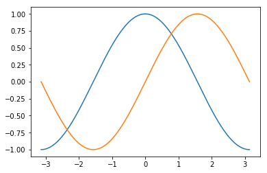

```python
plt.plot(x, y_cos)
plt.plot(x, y_sin)
```

### Set Figure Size

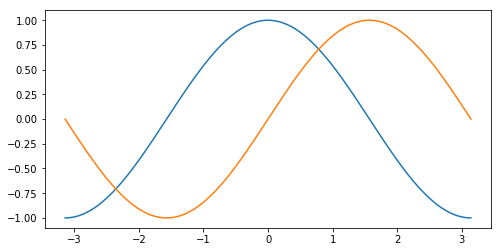

```python
plt.figure(figsize=(8,4))

plt.plot(x, y_cos)
plt.plot(x, y_sin)
```

### Set Axis Limits

```
(-1.5, 1.499886165172246)
```

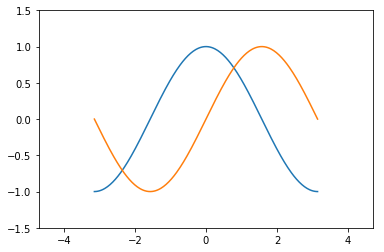

```python
plt.plot(x, y_cos)
plt.plot(x, y_sin)

plt.xlim(x.min()*1.5, x.max()*1.5)
plt.ylim(y_cos.min()*1.5, y_cos.max()*1.5)
```

### Set Ticks

Can use LaTeX rendering with r'\$...\$'

[output not shown]

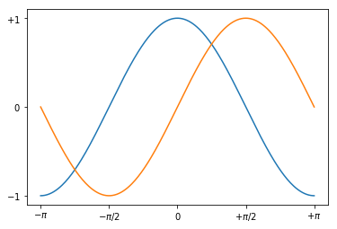

```python
plt.plot(x, y_cos)
plt.plot(x, y_sin)

# Set x axis tick positions and labels
plt.xticks([-np.pi, -np.pi/2, 0, np.pi/2, np.pi],
           [r'$-\pi$', r'$-\pi/2$', r'$0$', r'$+\pi/2$', r'$+\pi$'])

# Set y axis tick positions and labels
plt.yticks([-1, 0, +1],
           [r'$-1$', r'$0$', r'$+1$'])
```

### Set Tick Labels

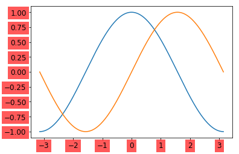

```python
plt.plot(x, y_cos)
plt.plot(x, y_sin)

ax = plt.gca()  # get current axis
for label in ax.get_xticklabels() + ax.get_yticklabels():
    label.set_fontsize(12)
    label.set_bbox(dict(facecolor='red', edgecolor='None', alpha=0.65))
```

### Set Spines

Lines connecting the axis tick marks and forming boundaries of the data area: top/bottom/left/right

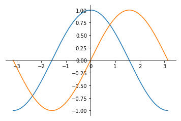

```python
plt.plot(x, y_cos)
plt.plot(x, y_sin)

# Get current axes
ax = plt.gca()

# Hide top and right spines
ax.spines['top'].set_visible(False)
ax.spines['right'].set_visible(False)

# Move left spine to where x=0 and show ticks on left
ax.spines['left'].set_position(('data',0))
ax.yaxis.set_ticks_position('left')

# Move bottom spine to where y=0 and show ticks below
ax.spines['bottom'].set_position(('data',0))
ax.xaxis.set_ticks_position('bottom')
```

### Set Legend

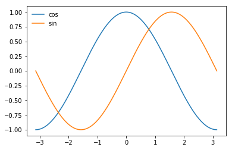

```python
plt.plot(x, y_cos, label="cos")
plt.plot(x, y_sin, label="sin")

plt.legend(loc='upper left', frameon=False)
```

### Annotate Points

```
Text(-90,-50,'$\\cos(\\frac{2\\pi}{3})=-\\frac{1}{2}$')
```

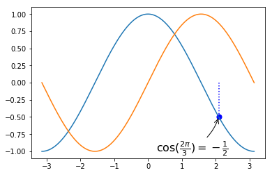

```python
plt.plot(x, y_cos)
plt.plot(x, y_sin)

# Set x and y coordinates of point to annotate
x_note = 2*np.pi/3
y_note = np.cos(x_note)

# Mark point
plt.scatter([x_note,], [y_note,],
            s=50, color='blue')

# Draw a dotted line from y=0 to the point
plt.plot([x_note, x_note], [0, y_note],
         color='blue', linewidth=1.5, linestyle="dotted")

# Annotate point with text offset to bottom left and draw curved arrow
plt.annotate(r'$\cos(\frac{2\pi}{3})=-\frac{1}{2}$',
             xy=(x_note, y_note), xycoords='data',
             xytext=(-90, -50), textcoords='offset points',
             fontsize=16,
             arrowprops=dict(arrowstyle="->", connectionstyle="arc3,rad=.2"))
```

References:

- http://www.labri.fr/perso/nrougier/teaching/matplotlib/matplotlib.html

# matplotlib: Scatterplots

Patrick Ho

2018-08-03

```python
%matplotlib inline
from matplotlib import pyplot as plt
```

### Scatterplots

```python
x_values = [4, 6, 7, 11, 17, 18, 18, 26, 39, 43]
y_values = [102, 106, 126, 133, 133, 143, 151, 152, 175, 177]
labels   = ['a', 'b', 'c', 'd', 'e', 'f', 'g', 'h', 'i', 'j']
```

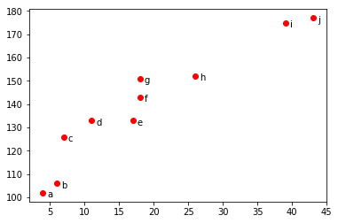

```python
plt.scatter(x_values, y_values, color='red')

# label points
for label, x_pos, y_pos in zip(labels, x_values, y_values):
    plt.annotate(label,
                 xy=(x_pos, y_pos),
                 xytext=(5, -5),
                 textcoords='offset points');
```

### Equal Axes

If units are the same, the default scale may be misleading. Use equal scale axes for a better representation.

```python
z_values = [18, 19, 33, 37, 71, 79, 85, 89, 95, 96]
```

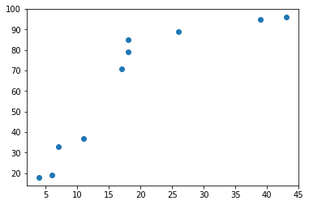

```python
plt.scatter(x_values, z_values);
```

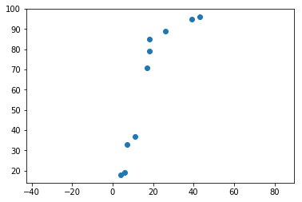

```python
plt.scatter(x_values, z_values)
plt.axis('equal');
```

- Newer posts
- Older posts